# National Database of Childcare Prices Analysis

This code is intended to serve the general population's understanding of the National Database of Childcare Prices. I aim to maintain consistent application of the Gestalt Principles, a level of conciseness and clarity that is maintained throughout to deliver a product that offers paramount transparency, that can be trusted, and is thoroughly explained to be undeniably understood.

```python
# **********

# Load necessary libraries

# **********

import pandas as pd

# **********

# Load the dataset

df = pd.read_excel("NDCP2022.xlsx")

# **********

# Cleaning

# **********

# Strip whitespace from column names

df.columns = df.columns.str.strip()

# Remove duplicate rows

df = df.drop_duplicates()

# Standardize string columns

str_cols = df.select_dtypes(include="object").columns
df[str_cols] = df[str_cols].apply(lambda col: col.str.strip())

# Drop empty columns

df = df.dropna(axis=1, how="all")

# **********

# Find unique STATE_NAME values

# **********

# Count unique states
num_states = df["STATE_NAME"].nunique()

# List the unique states

unique_states = df["STATE_NAME"].unique()

print(f"This is the number of unique items within the STATE_NAME column: {num_states}\n")
print("These are the unique STATE_NAME values or locations within the STATE_NAME column:")
for state in unique_states:
    print("-", state)
```

```
This is the number of unique items within the STATE_NAME column: 52

These are the unique STATE_NAME values or locations within the STATE_NAME column:
- Alabama
- Alaska
- Arizona
- Arkansas
- California
- Colorado
- Connecticut
- Delaware
- District of Columbia
- Florida
- Georgia
- Hawaii
- Idaho
- Illinois
- Indiana
- Iowa
- Kansas
- Kentucky
- Louisiana
- Maine
- Maryland
- Massachusetts
- Michigan
- Minnesota
- Mississippi
- Missouri
- Montana
- Nebraska
- Nevada
- New Hampshire
- New Jersey
- New Mexico
- New York
- North Carolina
- North Dakota
- Ohio
- Oklahoma
- Oregon
- Pennsylvania
- Rhode Island
- South Carolina
- South Dakota
- Tennessee
- Texas
- Utah
- Vermont
- Virginia
- Washington
- West Virginia
- Wisconsin
- Wyoming
- Puerto Rico
```

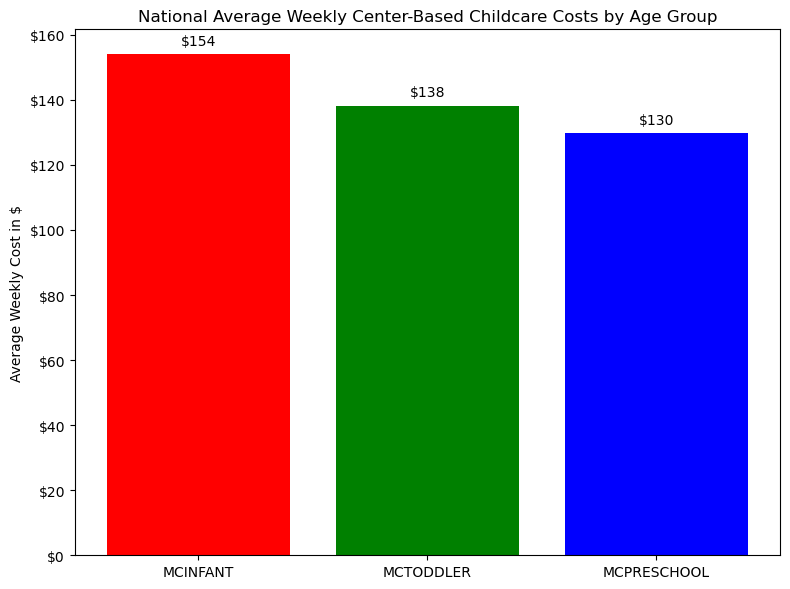

```python
# **********

# 1. Bar chart to reveal center-based childcare costs as a national average

# **********

# Load necessary libraries

# **********

import pandas as pd
import matplotlib.pyplot as plt
import matplotlib.ticker as mtick

# **********

# Select key variables

# **********

# MCINFANT = median price for childcare center associated with INFANT age children defined as 0 to 23 months of age
# MCTODDLER = median price for childcare center associated with TODDLER age children defined as 24 to 35 months of age
# MCPRESCHOOLER = median price for childcare center associated with PRESCHOOLER age children, defined as 36 to 60 months of age
cost_vars = ["MCINFANT", "MCTODDLER", "MCPRESCHOOL"]

# **********

# Compute the national averages per MCINFANT, MCTODDLER, and MCPRESCHOOL age grouping

avg_costs = df[cost_vars].mean()

# **********

# Bar chart to display average center-based childcare costs

# **********

# Set bar colors to red, green, and blue

rgb_colors = ["red", "green", "blue"]

# **********

# Create the bar chart
# Figsize is a setting to make a chart large enough to be read easily

# **********

plt.figure(figsize=(8,6))
bars = plt.bar(avg_costs.index, avg_costs.values, color=rgb_colors)

# Bar chart characteristics

for bar in bars:
    height = bar.get_height()
    plt.text(
        bar.get_x() + bar.get_width()/2,
        height + 2, # Slight offset added here above the bar
        f"${height:,.0f}", # Formatting for presentation of the $ amount above the bar
        ha='center',
        va='bottom',
        fontsize=10
    )

# **********

# This section adds titles and labels to the intended chart, and will be seen in other visualizations
# Here I have set the y-axis to be formatted as dollars in an intuitive way that reflects how one might actually think about childcare costs

# **********

plt.title("National Average Weekly Center-Based Childcare Costs by Age Group")
plt.ylabel("Average Weekly Cost in $")
plt.gca().yaxis.set_major_formatter(mtick.StrMethodFormatter('${x:,.0f}'))
plt.xticks(rotation=0)
plt.tight_layout()
plt.show()
```

Explanation:

Each bar represents an age grouping that most children in the nation will find themselves in. Alongside the bars, in the y-axis in dollars, is the average cost, on a national average, to care for your children in these age groupings on a weekly basis.

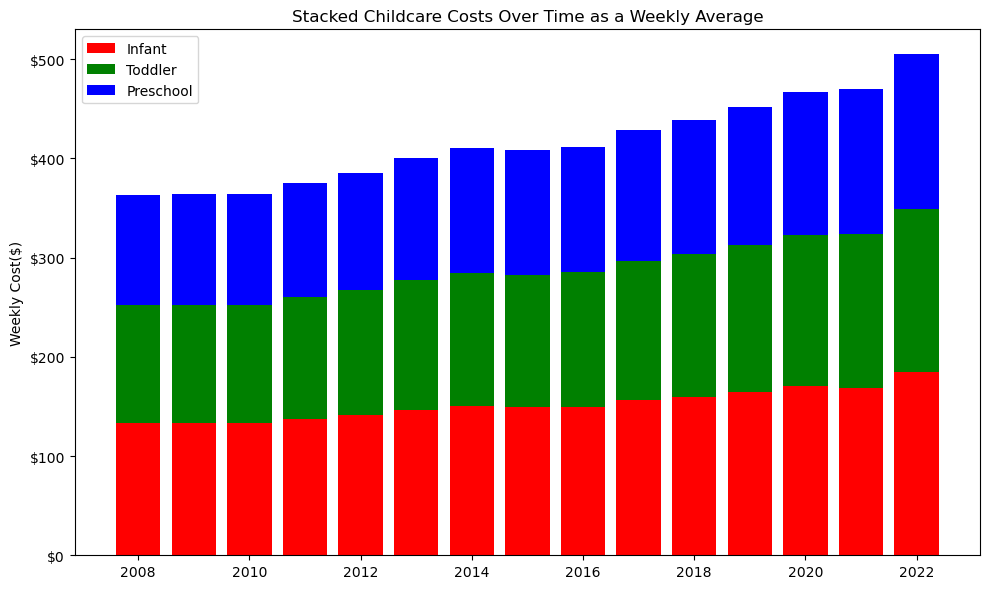

```python
# **********

# 2. Stacked bar chart utilizing a time component STUDYYEAR

# This visualization is created to reveal how each year has many points of data from many states
# The average is taken from each state to give a clean, national view of how much families pay in a given year

# **********

# Load necessary libraries

# **********

import matplotlib.pyplot as plt
import matplotlib.ticker as mtick

# **********

yearly = df.groupby("STUDYYEAR")[["MCINFANT", "MCTODDLER", "MCPRESCHOOL"]].mean()

plt.figure(figsize=(10,6))

# **********

# Infant cost will be plotted as the bottom layer of the stacked bar chart
# Stacking lets me show the total cost and how much each age grouping, to follow, contributes to the total cost

# **********

plt.bar(yearly.index, yearly["MCINFANT"], label="Infant", color="red")

# **********

# Toddler cost will be added on top of the Infant cost layer, seen as 'bottom='

# **********

plt.bar(yearly.index, yearly["MCTODDLER"],
        bottom=yearly["MCINFANT"],
        label="Toddler", color="green")

# **********

# Preschool cost will be stacked on top of both Infant and Toddler
# This creates the full stack I am aiming to show, revealing the weekly cost of childcare across all three of the age groups

# **********

plt.bar(yearly.index, yearly["MCPRESCHOOL"],
        bottom=yearly["MCINFANT"] + yearly["MCTODDLER"],
        label="Preschool", color="blue")

plt.title("Stacked Childcare Costs Over Time as a Weekly Average")
plt.ylabel("Weekly Cost($)")
plt.gca().yaxis.set_major_formatter(mtick.StrMethodFormatter('${x:,.0f}'))
plt.legend()
plt.tight_layout()
plt.show()
```

Explanation:

This visualization represents how the total weekly cost of center-based childcare has changed over time. Infant, Toddler, and Preschool are stacked here to help see both the individual costs and the combined burden caregivers may face. The overall height of the stack in any given year represents the overall level of childcare cost nationally, and the thickness of each band shows how each Infant, Toddler, and Preschool contributes to the total. Having Infant at the bottom helps caregivers understand the pressures they feel about Infant expenses year over year are founded and real.

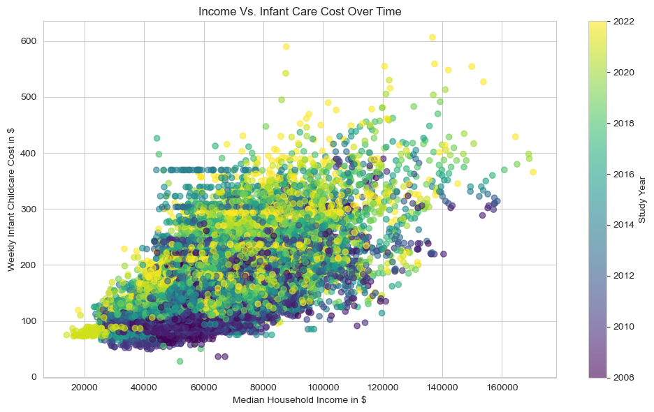

```python
# **********

# 3. Scatterplot with time where color is associated with STUDYYEAR

# **********

# Load necessary libraries

# **********

import seaborn as sns
import matplotlib.pyplot as plt
import matplotlib.ticker as mtick
import numpy as np

# **********

# Here I set a visual style that is clean so that the chart is easy to read
# This is important as maintaining a consistent style will help the general public focus on the story rather than the formatting

# **********

sns.set_style("whitegrid")

# **********

# Here I add jitter, a way to reduce overlapping dots within the scatterplot
# This will spread the dots horizontally so clusters are easier to see

# **********

np.random.seed(69) # Seed is set to a specific number so anyone can reproduce
income_jittered = df["MHI_2022"] + np.random.normal(0, 1000, size=len(df))

# **********

# Here I create the scatterplot with the following characteristics:

# x-axis is MHI; median household income
# y-axis is MCINFANT; the weekly cost of infant childcare
# color shows the STUDYYEAR; how costs shift over time
# These each help maintain consistent styling to help the general public see how costs cluster and shift over time

# **********

plt.figure(figsize=(10,6))

scatter = plt.scatter(
    df["MHI_2022"],
    df["MCINFANT"],
    c=df["STUDYYEAR"],
    cmap="viridis",
    alpha=0.6
)

plt.colorbar(scatter, label="Study Year")
plt.title("Income Vs. Infant Care Cost Over Time")
plt.xlabel("Median Household Income in $")
plt.ylabel("Weekly Infant Childcare Cost in $")
plt.tight_layout()
plt.show()
```

Explanation:

Each dot in the Scatterplot shows the weekly cost of infant care for a given income level and year. I have selected the color map as Viridis, which varies from previous visuals. This is because I don't want those who view this chart to associate red, green, or blue with Infant, Toddler, or Preschool here, as this chart is only associated with Infant.

The question begs, why isn't there a scatter plot for MCTODDLER and MCPRESCHOOL? This is because they would tell the same story: those with higher income tend to have higher childcare costs, regardless of the age grouping of the child. The patterns are nearly identical but with different pricing levels. Providing three visualizations would add clutter but no additional insight.

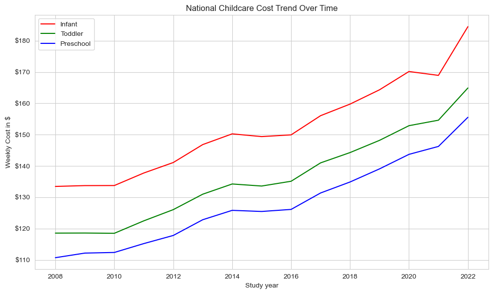

```python
# **********

# 4. Multi-line chart displaying national childcare trends over time

# **********

# Load necessary libraries

# **********

import seaborn as sns
import matplotlib.pyplot as plt
import matplotlib.ticker as mtick

# **********

sns.set_style("whitegrid")

# **********

# Here I prepare national averages for each age group, Infant, Toddler, and Preschool across all states, or what is referred to as the nation
# When referring to the nation, please note that this only refers to the states or territories contained within STATE_NAME
# This will give a clear national-level picture of how childcare costs have changed over time for each age group

# **********

plt.figure(figsize=(10,6))

# **********

# Here I plot the national trend of Infant, then Toddler, and then Preschool care

# **********

plt.plot(yearly.index, yearly["MCINFANT"], color="red", label="Infant")
plt.plot(yearly.index, yearly["MCTODDLER"], color="green", label="Toddler")
plt.plot(yearly.index, yearly["MCPRESCHOOL"], color="blue", label="Preschool")

# **********

# Titles and labels are added to be as self-explanatory as possible, and the y-axis is formatted as dollars

# **********

plt.title("National Childcare Cost Trend Over Time")
plt.xlabel("Study year")
plt.ylabel("Weekly Cost in $")
plt.gca().yaxis.set_major_formatter(mtick.StrMethodFormatter('${x:,.0f}'))
plt.legend()
plt.tight_layout()
plt.show()
```

Explanation:

These lines show the change in cost nationally. Infant care remains the most expensive option year over year, followed by Toddler care and then Preschool care. But all three clearly show an upward trend. The sharp rise after 2020 highlights how national economic pressures such as inflation, COVID, staffing shortage, and potentially operational costs due to a combination, affect childcare prices across the nation. Understanding how the national trend affects states is essential because it gives caretakers a baseline for what is supposed to be "normal". Without national context, its neraly impossible to tell whether a particular state falls within a reasonable range, is very afforable or is outrageous.

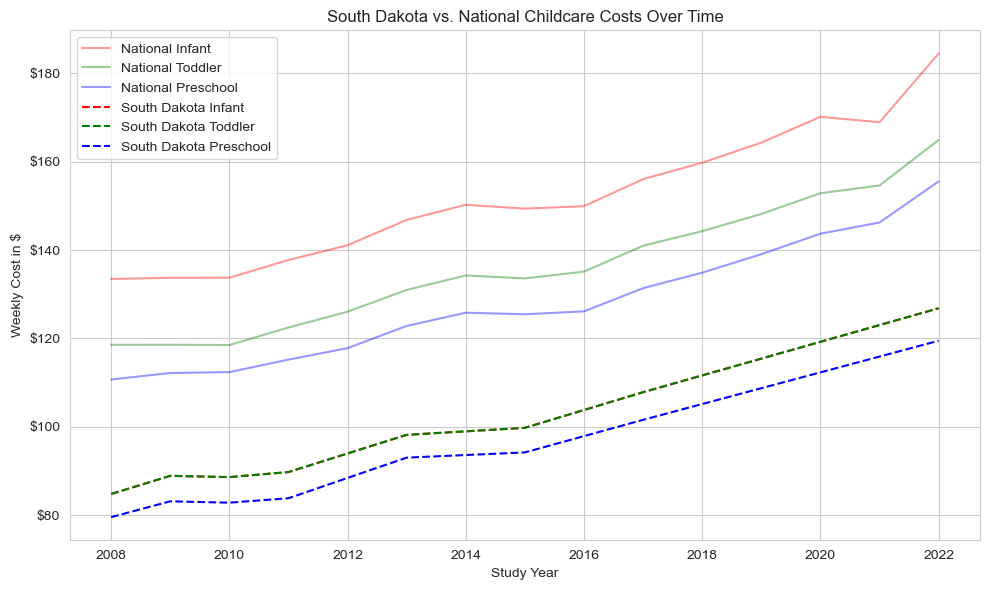

```python
# **********

# 5. Single state vs. National comparison of childcare cost over time

# **********

# Load necessary libraries

# **********

import seaborn as sns
import matplotlib.pyplot as plt
import matplotlib.ticker as mtick
import random

# **********

sns.set_style("whitegrid")

# **********

# Randomly select a state or territory each time the code is run
# This will add variety to help viewers of the General Public see how childcare costs differ

# **********

state = random.choice(df["STATE_NAME"].dropna().unique())

# **********

# Here I prepare the national averages by age group
# I group by STUDYYEAR and calculate average weekly costs for Infant, Toddler, and Preschool care across those available in STATE_NAME
# This gives viewers of the General Public a baseline to compare their state against

# **********

yearly = (
    df.groupby("STUDYYEAR")[["MCINFANT", "MCTODDLER", "MCPRESCHOOL"]]
    .mean()
)

# **********

# Here I prepare the selected states' averages for each age group, Infant, Toddler, and Preschool
# This shows the state trend alongside the national trend to help viewers of the General Public see whether their state may be more, less, or moving similarly to the average

# **********

state_yearly = (
    df[df["STATE_NAME"] == state]
    .groupby("STUDYYEAR")[["MCINFANT", "MCTODDLER", "MCPRESCHOOL"]]
    .mean()
)

plt.figure(figsize=(10,6))

# **********

# Infant, Toddler, and Preschool trends will be plotted, where the solid line is the nation

# **********

plt.plot(yearly.index, yearly["MCINFANT"], color="red", alpha=0.4, label="National Infant")
plt.plot(yearly.index, yearly["MCTODDLER"], color="green", alpha=0.4, label="National Toddler")
plt.plot(yearly.index, yearly["MCPRESCHOOL"], color="blue", alpha=0.4, label="National Preschool")

# **********

# Infant, Toddler, and Preschool trends will be plotted, where the dashed line is the state or territory
# If the selected state has no data to show, show only the national lines and add a note with an explanation

if state_yearly.isna().all().all():
    plt.text(
        0.5, 0.5,
        f"No state or territory level data is available for {state}",
        ha="center", va="center",
        fontsize=12, color="black",
        transform=plt.gca().transAxes
    )
else:
    # Plot the state lines only when data is available
    plt.plot(state_yearly.index, state_yearly["MCINFANT"], color="red", linestyle="--", label=f"{state} Infant")
    plt.plot(state_yearly.index, state_yearly["MCTODDLER"], color="green", linestyle="--", label=f"{state} Toddler")
    plt.plot(state_yearly.index, state_yearly["MCPRESCHOOL"], color="blue", linestyle="--", label=f"{state} Preschool")

plt.title(f"{state} vs. National Childcare Costs Over Time")
plt.xlabel("Study Year")
plt.ylabel("Weekly Cost in $")
plt.gca().yaxis.set_major_formatter(mtick.StrMethodFormatter('${x:,.0f}'))
plt.legend()
plt.tight_layout()
plt.show()
```

Explanation:

The output of this chart is set to select a random state or territory from STATE_NAME, but the state can easily be swapped within the code for any specific state within STATE_NAME. Please see STATE_NAME values at the beginning of this codeset for options. The outputs from this visualization can be used to make tough decisions, like moving, much easier. The output displays how a state or territory's childcare costs compare to the national average. This reveals whether one might have more or less affordable care in comparison to the national average. Please note that some states or territories might have missing values. If a value is missing, the associated line will not appear.

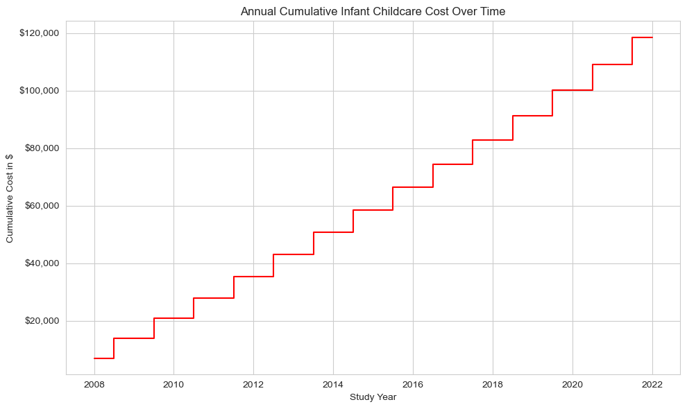

```python
# **********

# 5. Step chart showing how cumulative Infant childcare costs change over time

# **********

# Load necessary libraries

# **********

import seaborn as sns
import matplotlib.pyplot as plt
import matplotlib.ticker as mtick

# **********

sns.set_style("whitegrid")

# **********

annual_yearly = yearly * 52
cumulative = annual_yearly["MCINFANT"].cumsum()

# **********

# Plot of the Infant care step line
# Infant care is the most expensive category, so the year-over-year will change and display visible jumps

# **********

plt.figure(figsize=(10, 6))
plt.step(cumulative.index, cumulative.values, where="mid", color="red")

plt.title("Annual Cumulative Infant Childcare Cost Over Time")
plt.xlabel("Study Year")
plt.ylabel("Cumulative Cost in $")
plt.gca().yaxis.set_major_formatter(mtick.StrMethodFormatter('${x:,.0f}'))
plt.tight_layout()
plt.show()
```

Explanation:

If one were to stack each year's national average annual infant childcare cost specifically, on top of each other, the value in 2022 represents the total of these averages starting in 2008. Another way to say this is that if one were to actually pay the national average as their infant childcare cost every year from 2008 to 2022, this chart stacks those costs, displays them, and shows how they add up in 2022.

This matters because the cumulative costs help those who might be interested in having children, or who want to know the future cost of infants they already have, and how infant childcare costs stack up over time. This reveals the financial burden and how it compounds yearly. This chart clearly reveals why someone who cares for children might feel the financial squeeze worsen over time, and that is because the costs do compound.

What this chart is not:

1. Cost of raising a single child
2. Cost for any specific family
3. Cost of any specific state

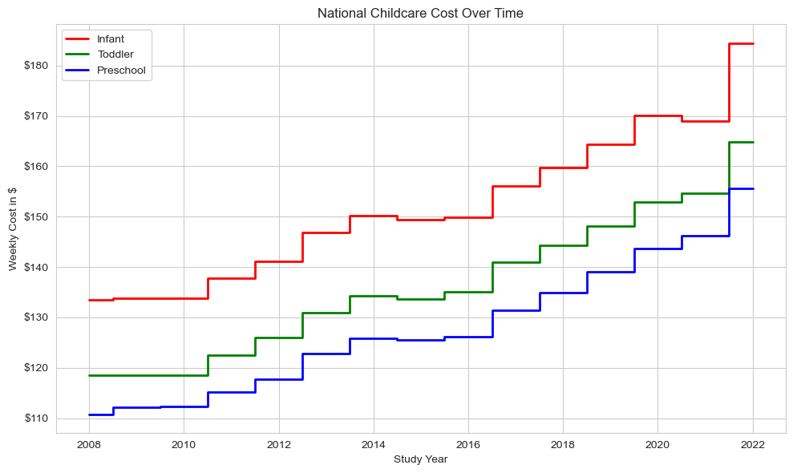

```python
# **********

# 6. Step chart showing how childcare costs change over time

# **********

# Load necessary libraries

# **********

import seaborn as sns
import matplotlib.pyplot as plt
import matplotlib.ticker as mtick

# **********

sns.set_style("whitegrid")

# **********

# Here I prepare the national average for each age group: Infant, Toddler, and Preschool
# They are grouped by STUDYYEAR and calculated for the average weekly cost
# This highlights how costs change from one year to the next and makes it easier for viewers of the General Public to see when costs change

# **********

national = (
    df.groupby("STUDYYEAR")[["MCINFANT", "MCTODDLER", "MCPRESCHOOL"]]
    .mean()
)

# **********

# Creation of the chart and plot for each step line

# **********

plt.figure(figsize=(10, 6))

plt.step(national.index, national["MCINFANT"], where="mid", color="red", linewidth=2, label="Infant")
plt.step(national.index, national["MCTODDLER"], where="mid", color="green", linewidth=2, label="Toddler")
plt.step(national.index, national["MCPRESCHOOL"], where="mid", color="blue", linewidth=2, label="Preschool")

plt.title("National Childcare Cost Over Time")
plt.xlabel("Study Year")
plt.ylabel("Weekly Cost in $")
plt.gca().yaxis.set_major_formatter(mtick.StrMethodFormatter('${x:,.0f}'))
plt.legend()
plt.tight_layout()
plt.show()
```

Explanation:

This chart shows how weekly childcare costs have steadily increased for caretakers of Infant's, Toddler's, and Preschooler's from 2008 to 2022. Infant care is consistently the most expensive, with costs increasing from $150.00 per week to over $180.00 per week from 2014 to 2022. Toddler care follows a similar trend, but remains cheaper than Infant care. Preschool care is the least expensive, but still shows a clear increase in cost over time. Together, these lines highlight the long term rising cost of childcare for caretakers across all age groupings and truly show the growing financial pressures on caretakers.